# Griffin Olimpio and Duke Glenn US Business Dynamics and the S&P 500 Index 2000-2018

https://golimpio100.github.io/

# Project Goals

The goal of this project is to see if the S&P500 actually has large effects on employment and the number of new companies opening.

# Project Datasets

The first dataset we are looking at is Business Dynamics Statistics (BDS) dataset curated by Austin Cory Bart, Joung Min Choi and Bo Guan. This dataset has been recording changes in employment, firm creation, and destruction on the state level from 1978-2018. The other dataset we will be observing is historical data of the S&P 500 index. The Standard and Poor's 500 is a index that uses the stock prices of the 500 highest market cap companies publically traded in the United States. This index is widely regarded as a standard for the stock market as a whole and has all data going back to 1871. We are also using the US employment rate(ages 15-65) from the same time period.

# Column Descriptions

Some columns are self explanatory but here are definitions for clarity

*S&P 500*

**Year** : The year recorded

**SP500** : Price of the S&P 500 index, which is a weighted average of the stock prices within the index

**Long Interest Ratew** : The rate of interest that is commonly available in the market for a similar investment or loan at a given time

**Earnings** : composite earnings per share

**Consumer Price Index** : Value of market in current year over value at base year

> .

*Business Dynmics Statistics*

**State** : State in which data is from

**Year** : The year recorded

**DHS Denom** : Two-period trailing moving average of employment

**Number of Firms** : Count of firms

**Net Job Creation** : Sum of the Job Creation Rate minus the Job Destruction Rate

**Establishments Entered** : count of establishments that entered during the year

**Establishments Entered Rate** : number of establishments that entered during the year divided by the number of establishments

**Establishments Exited** : count of establishments that exited during the year

**Establishments Exited Rate** : number of establishments that exited during the year divided by the number of establishments

**Firm Exits** : Count of firms exited that year

**Jobs Created** : Count of jobs created that year

**Job Creation Rate** : number of jobs that were created in the last year divided by the DHS denominator

```python
import pandas as pd
import numpy as np
import matplotlib.pyplot as plt
bsd_df = pd.read_csv('https://think.cs.vt.edu/corgis/datasets/csv/business_dynamics/business_dynamics.csv')
snp_df = pd.read_csv('https://datahub.io/core/s-and-p-500/r/data.csv')
em_df = pd.read_csv('https://fred.stlouisfed.org/graph/fredgraph.csv?bgcolor=%23e1e9f0&chart_type=line&drp=0&fo=open%20sans&graph_bgcolor=%23ffffff&height=450&mode=fred&recession_bars=on&txtcolor=%23444444&ts=12&tts=12&width=1318&nt=0&thu=0&trc=0&show_legend=yes&show_axis_titles=yes&show_tooltip=yes&id=LREM64TTUSM156S&scale=left&cosd=1977-01-01&coed=2023-10-01&line_color=%234572a7&link_values=false&line_style=solid&mark_type=none&mw=3&lw=2&ost=-99999&oet=99999&mma=0&fml=a&fq=Monthly&fam=avg&fgst=lin&fgsnd=2020-02-01&line_index=1&transformation=lin&vintage_date=2023-12-01&revision_date=2023-12-01&nd=1977-01-01')
```

First, let's load in our data sets and make the necessary imports.

```python
snp_df.head()
```

|  | Date | SP500 | Dividend | Earnings | Consumer Price Index | Long Interest Rate | Real Price | Real Dividend | Real Earnings | PE10 |
| --- | --- | --- | --- | --- | --- | --- | --- | --- | --- | --- |
| 0 | 1871-01-01 | 4.44 | 0.26 | 0.4 | 12.46 | 5.32 | 89.00 | 5.21 | 8.02 | NaN |
| 1 | 1871-02-01 | 4.50 | 0.26 | 0.4 | 12.84 | 5.32 | 87.53 | 5.06 | 7.78 | NaN |
| 2 | 1871-03-01 | 4.61 | 0.26 | 0.4 | 13.03 | 5.33 | 88.36 | 4.98 | 7.67 | NaN |
| 3 | 1871-04-01 | 4.74 | 0.26 | 0.4 | 12.56 | 5.33 | 94.29 | 5.17 | 7.96 | NaN |
| 4 | 1871-05-01 | 4.86 | 0.26 | 0.4 | 12.27 | 5.33 | 98.93 | 5.29 | 8.14 | NaN |

```python
bsd_df.head()
```

|  | State | Year | Data.DHS Denominator | Data.Number of Firms | Data.Calculated.Net Job Creation | Data.Calculated.Net Job Creation Rate | Data.Calculated.Reallocation Rate | Data.Establishments.Entered | Data.Establishments.Entered Rate | Data.Establishments.Exited | ... | Data.Job Creation.Births | Data.Job Creation.Continuers | Data.Job Creation.Count | Data.Job Creation.Rate | Data.Job Creation.Rate/Births | Data.Job Destruction.Continuers | Data.Job Destruction.Count | Data.Job Destruction.Deaths | Data.Job Destruction.Rate | Data.Job Destruction.Rate/Deaths |
| --- | --- | --- | --- | --- | --- | --- | --- | --- | --- | --- | --- | --- | --- | --- | --- | --- | --- | --- | --- | --- | --- |
| 0 | Alabama | 1978 | 972627 | 54597 | 74178 | 7.627 | 29.183 | 10457 | 16.375 | 7749 | ... | 76167 | 139930 | 216097 | 22.218 | 7.831 | 81829 | 141919 | 60090 | 14.591 | 6.178 |
| 1 | Alabama | 1979 | 1037995 | 55893 | 58099 | 5.597 | 31.251 | 9668 | 14.701 | 7604 | ... | 76618 | 143675 | 220293 | 21.223 | 7.381 | 101842 | 162194 | 60352 | 15.626 | 5.814 |
| 2 | Alabama | 1980 | 1064141 | 54838 | -7253 | -0.682 | 32.464 | 8714 | 13.168 | 8871 | ... | 65734 | 106998 | 172732 | 16.232 | 6.177 | 120563 | 179985 | 59422 | 16.914 | 5.584 |
| 3 | Alabama | 1981 | 1051448 | 54791 | -9132 | -0.869 | 31.206 | 8371 | 12.687 | 7516 | ... | 70115 | 93941 | 164056 | 15.603 | 6.668 | 121251 | 173188 | 51937 | 16.471 | 4.940 |
| 4 | Alabama | 1982 | 1037728 | 53219 | -9658 | -0.931 | 33.144 | 8185 | 12.497 | 8621 | ... | 73083 | 98887 | 171970 | 16.572 | 7.043 | 119658 | 181628 | 61970 | 17.502 | 5.972 |

5 rows × 25 columns

```python
em_df.head()
```

|  | DATE | LREM64TTUSM156S |
| --- | --- | --- |
| 0 | 1977-01-01 | 64.566791 |
| 1 | 1977-02-01 | 64.683217 |
| 2 | 1977-03-01 | 64.914083 |
| 3 | 1977-04-01 | 65.158112 |
| 4 | 1977-05-01 | 65.267202 |

Some of the data is a little messy, so lets do some cleaning:

First off, we will be averaging out monthy S&P data to an annual basis to line up with BDS data

```python
snp_df['Year'] = pd.DatetimeIndex(snp_df['Date']).year
snp_df['Month'] = pd.DatetimeIndex(snp_df['Date']).month
snp = snp_df.groupby('Year').mean()



em_df['Year']= pd.DatetimeIndex(em_df['DATE']).year
em_df['Month'] = pd.DatetimeIndex(em_df['DATE']).month
em = em_df.groupby('Year').mean()
```

Next, dropping data that is not being observed. This is due to irrelevance to comparison between the two datasets.

```python
snp.drop(['Dividend', 'Real Price', 'Real Dividend', 'Real Earnings', 'PE10','Month'], axis=1, inplace=True)
```

```python
bsd_df.drop(['Data.Calculated.Net Job Creation Rate', 'Data.Calculated.Reallocation Rate', 'Data.Establishments.Physical Locations', 'Data.Firm Exits.Establishment Exit', 'Data.Firm Exits.Employments', 'Data.Job Creation.Births', 'Data.Job Creation.Continuers', 'Data.Job Creation.Rate/Births', 'Data.Job Destruction.Continuers', 'Data.Job Destruction.Count', 'Data.Job Destruction.Deaths', 'Data.Job Destruction.Rate', 'Data.Job Destruction.Rate/Deaths'], axis=1, inplace=True)
```

```python
em.drop(['Month'], axis=1, inplace=True)
```

To make the columns a little more readable, we will be renaming a few columns from the BDS set

```python
bsd_df = bsd_df.rename(columns = { "Data.DHS Denominator" : "DHS Denom",
                                    "Data.Number of Firms" : "Number of Firms",
                                     "Data.Calculated.Net Job Creation" : "Net Job Creation",
                                     "Data.Establishments.Entered" : "Establishments Entered",
                                     "Data.Establishments.Entered Rate" : "Establishments Entered Rate",
                                     "Data.Establishments.Exited" : "Establishments Exited",
                                     "Data.Establishments.Exited Rate" : "Establishments Exited Rate",
                                     "Data.Firm Exits.Count" : "Firms Exits",
                                     "Data.Job Creation.Count" : "Jobs Created",
                                     "Data.Job Creation.Rate" : "Job Creation Rate"
})

em = em.rename(columns = {"LREM64TTUSM156S" : "Employment Rate"})
```

Next we need to convert the BSD data to a national scale.

```python
national_bsd_df=bsd_df.groupby(bsd_df['Year']).sum()
national_bsd_df['Establishments Entered Rate'] = national_bsd_df['Establishments Entered Rate']/50
national_bsd_df['Establishments Exited Rate'] = national_bsd_df['Establishments Exited Rate']/50
national_bsd_df['Job Creation Rate'] = national_bsd_df['Job Creation Rate']/50
```

```python
for i in snp:
  snp['Interest Change'] = ((snp['Long Interest Rate'] - snp['Long Interest Rate'].shift(-1))/snp['Long Interest Rate'].shift(-1))*100
  snp['CPI Change'] = ((snp['Consumer Price Index'] - snp['Consumer Price Index'].shift(-1))/snp['Consumer Price Index'].shift(-1))*100
```

Since we're only using data from 2000-2018, lets restrict the S&P data to our timeframe

```python
modern_snp = snp.loc['2000':'2018']
modern_snp.head()
```

| Year | SP500 | Earnings | Consumer Price Index | Long Interest Rate | Interest Change | CPI Change |
| --- | --- | --- | --- | --- | --- | --- |
| 2000 | 1427.007500 | 51.490000 | 172.200000 | 6.029167 | 20.162764 | -2.748494 |
| 2001 | 1192.078333 | 35.916667 | 177.066667 | 5.017500 | 8.819808 | -1.561269 |
| 2002 | 995.630000 | 27.025833 | 179.875000 | 4.610833 | 14.840183 | -2.219706 |
| 2003 | 963.689167 | 36.285000 | 183.958333 | 4.015000 | -6.063560 | -2.607430 |
| 2004 | 1130.547500 | 55.300000 | 188.883333 | 4.274167 | -0.369075 | -3.281417 |

Now we're going to normalize the S&P data via min-max scaling

```python
df_min_max_scaled = modern_snp.copy()

# apply normalization techniques
for column in df_min_max_scaled.columns:
    df_min_max_scaled[column] = (df_min_max_scaled[column] - df_min_max_scaled[column].min()) / (df_min_max_scaled[column].max() - df_min_max_scaled[column].min())

# view normalized data
print(df_min_max_scaled)
```

```
         SP500  Earnings  Consumer Price Index  Long Interest Rate  \
Year
2000  0.272380  0.399960              0.000000            1.000000
2001  0.139143  0.222137              0.063317            0.760647
2002  0.027730  0.120617              0.099854            0.664432
2003  0.009615  0.226342              0.152979            0.523462
2004  0.104246  0.443464              0.217054            0.584779
2005  0.147640  0.542862              0.300428            0.588525
2006  0.206400  0.677961              0.382393            0.707216
2007  0.300524  0.719677              0.457234            0.668770
2008  0.155482  0.353515              0.560763            0.441049
2009  0.000000  0.000000              0.550810            0.344046
2010  0.109214  0.578335              0.596596            0.333991
2011  0.182705  0.770917              0.686139            0.232650
2012  0.245472  0.810044              0.746701            0.000000
```

[output cut: 28 more lines]

```python
national_bsd_df.head()
```

| Year | DHS Denom | Number of Firms | Net Job Creation | Establishments Entered | Establishments Entered Rate | Establishments Exited | Establishments Exited Rate | Firms Exits | Jobs Created | Job Creation Rate |
| --- | --- | --- | --- | --- | --- | --- | --- | --- | --- | --- |
| 1978 | 63623982 | 3468661 | 4890247 | 619312 | 14.90834 | 464562 | 10.96870 | 312668 | 13977564 | 21.62646 |
| 1979 | 67864608 | 3575606 | 4007005 | 593369 | 13.72708 | 424937 | 9.83448 | 285625 | 13215426 | 18.60928 |
| 1980 | 70080779 | 3589225 | 387682 | 552961 | 12.32880 | 472336 | 10.83810 | 329217 | 11531276 | 15.67912 |
| 1981 | 70504576 | 3641065 | 798676 | 548290 | 12.01528 | 429210 | 9.62642 | 281901 | 11417554 | 15.44372 |
| 1982 | 70990844 | 3635666 | 465009 | 569180 | 12.48792 | 501537 | 11.09402 | 347321 | 12092409 | 16.07354 |

```python
bsd_df.head()
```

|  | State | Year | DHS Denom | Number of Firms | Net Job Creation | Establishments Entered | Establishments Entered Rate | Establishments Exited | Establishments Exited Rate | Firms Exits | Jobs Created | Job Creation Rate |
| --- | --- | --- | --- | --- | --- | --- | --- | --- | --- | --- | --- | --- |
| 0 | Alabama | 1978 | 972627 | 54597 | 74178 | 10457 | 16.375 | 7749 | 12.135 | 5248 | 216097 | 22.218 |
| 1 | Alabama | 1979 | 1037995 | 55893 | 58099 | 9668 | 14.701 | 7604 | 11.562 | 5234 | 220293 | 21.223 |
| 2 | Alabama | 1980 | 1064141 | 54838 | -7253 | 8714 | 13.168 | 8871 | 13.406 | 6058 | 172732 | 16.232 |
| 3 | Alabama | 1981 | 1051448 | 54791 | -9132 | 8371 | 12.687 | 7516 | 11.391 | 5176 | 164056 | 15.603 |
| 4 | Alabama | 1982 | 1037728 | 53219 | -9658 | 8185 | 12.497 | 8621 | 13.163 | 6077 | 171970 | 16.572 |

```python
em.head()
```

| Year | Employment Rate |
| --- | --- |
| 1977 | 65.417180 |
| 1978 | 67.118328 |
| 1979 | 67.924363 |
| 1980 | 67.183178 |
| 1981 | 67.070233 |

Here we are making a scatterplot to examine the correlation between the SNP and employment rate data.

```python
plt.scatter(em['Employment Rate'].loc['2000':'2018'], modern_snp['SP500'])

#obtain m (slope) and b(intercept) of linear regression line
m, b = np.polyfit(em['Employment Rate'].loc['2000':'2018'], modern_snp['SP500'], 1)

#add linear regression line to scatterplot
plt.plot(em['Employment Rate'].loc['2000':'2018'], m*(em['Employment Rate'].loc['2000':'2018'])+b)
```

[output not shown]

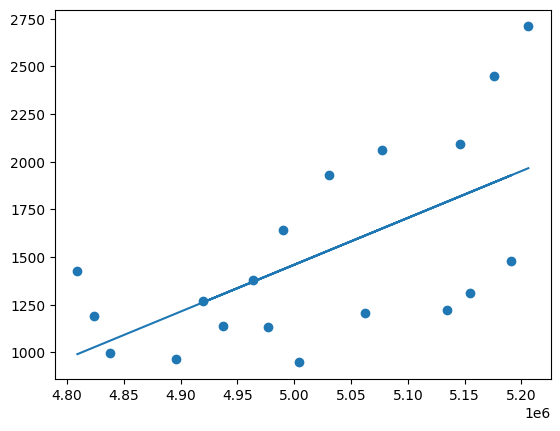

```python
plt.scatter(national_bsd_df['Number of Firms'].loc['2000':'2018'], modern_snp['SP500'])

m, b = np.polyfit(national_bsd_df['Number of Firms'].loc['2000':'2018'], modern_snp['SP500'], 1)

plt.plot(national_bsd_df['Number of Firms'].loc['2000':'2018'], m*(national_bsd_df['Number of Firms'].loc['2000':'2018'])+b)
```

The common reason for rising or falling interest rates is commonly stated to be its effect on the stock market. The reason that rising interest rates have been happening is to slow down inflation by slowing down the economy. In this chart we have overlaid the interest rate and the S&P500 price to see if these two numbers are indeed negatively correlated.

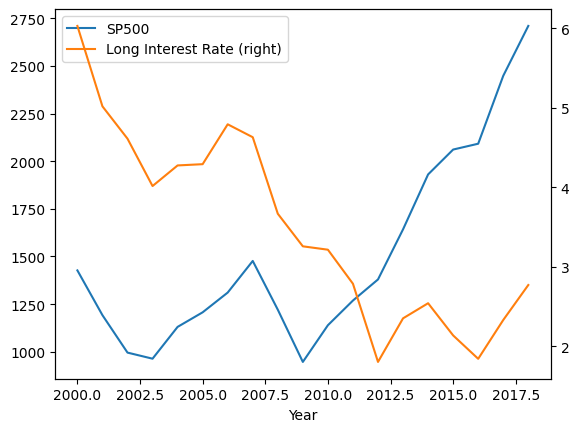

```python
fig, ax = plt.subplots()

# Plot the first x and y axes:
modern_snp.plot(use_index = True, y = 'SP500', ax = ax)
modern_snp.plot(use_index = True, y = 'Long Interest Rate', ax = ax, secondary_y = True)
```

We can see that there is a negative correlation between the interest rates and S&P price, however it isn't as strong as we expected.

This raised the question if the interest rates affect other financial aspects which in turn affect the stock market.

```python
plt.scatter(modern_snp['Long Interest Rate'], national_bsd_df['Number of Firms'].loc['2000':'2018'])

m, b = np.polyfit(modern_snp['Long Interest Rate'], national_bsd_df['Number of Firms'].loc['2000':'2018'], 1)

plt.plot(modern_snp['Long Interest Rate'], m*(modern_snp['Long Interest Rate'])+b)
```

[output not shown]

Now we want to see how CPI and Interest Rates are related. We have normalized the data for this chart and calculated the % change year-by-year.

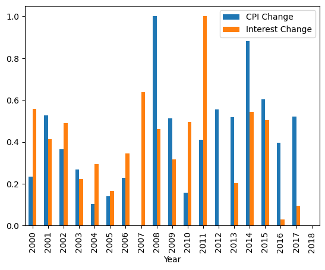

```python
df_min_max_scaled.plot(use_index = True, y=["CPI Change", "Interest Change"], kind="bar")
```

We want to run modeling to predict the S&P Price based off of employment data and interest rates. We also want to see the statistical relationship between CPI and Job Creation.

To start off the modeling, we reloaded the datatsets and combined them into one. For the sake of the model having more than 18 points to go off of, we expanded the dataset to 1978-2018. Once again, columns were renamed and datasets were brought to a country-wide and annual level.

```python
import pandas as pd
import numpy as np
from sklearn.preprocessing import StandardScaler

#loading the datasets
bsd_df = pd.read_csv('https://think.cs.vt.edu/corgis/datasets/csv/business_dynamics/business_dynamics.csv')
snp_df = pd.read_csv('https://datahub.io/core/s-and-p-500/r/data.csv')
em_df = pd.read_csv('https://fred.stlouisfed.org/graph/fredgraph.csv?bgcolor=%23e1e9f0&chart_type=line&drp=0&fo=open%20sans&graph_bgcolor=%23ffffff&height=450&mode=fred&recession_bars=on&txtcolor=%23444444&ts=12&tts=12&width=1318&nt=0&thu=0&trc=0&show_legend=yes&show_axis_titles=yes&show_tooltip=yes&id=LREM64TTUSM156S&scale=left&cosd=1977-01-01&coed=2023-10-01&line_color=%234572a7&link_values=false&line_style=solid&mark_type=none&mw=3&lw=2&ost=-99999&oet=99999&mma=0&fml=a&fq=Monthly&fam=avg&fgst=lin&fgsnd=2020-02-01&line_index=1&transformation=lin&vintage_date=2023-12-01&revision_date=2023-12-01&nd=1977-01-01')

# reprocessing S&P 500 Data
snp_df['Year'] = pd.DatetimeIndex(snp_df['Date']).year
snp_df = snp_df.groupby('Year').mean()

# reprocessing Employment Data
em_df['Year'] = pd.DatetimeIndex(em_df['DATE']).year
em_df = em_df.groupby('Year').mean()

# renaming columns for clarity
bsd_df = bsd_df.rename(columns={
    "Data.DHS Denominator": "DHS Denom",
    "Data.Number of Firms": "Number of Firms",
    "Data.Calculated.Net Job Creation": "Net Job Creation",
    "Data.Establishments.Entered": "Establishments Entered",
    "Data.Establishments.Entered Rate": "Establishments Entered Rate",
    "Data.Establishments.Exited": "Establishments Exited",
    "Data.Establishments.Exited Rate": "Establishments Exited Rate",
    "Data.Firm Exits.Count": "Firms Exits",
    "Data.Job Creation.Count": "Jobs Created",
    "Data.Job Creation.Rate": "Job Creation Rate"
})

# converting the BSD data to a national scale
national_bsd_df = bsd_df.groupby('Year').sum()
national_bsd_df['Establishments Entered Rate'] = national_bsd_df['Establishments Entered Rate'] / 50
national_bsd_df['Establishments Exited Rate'] = national_bsd_df['Establishments Exited Rate'] / 50
national_bsd_df['Job Creation Rate'] = national_bsd_df['Job Creation Rate'] / 50

# switching the data for the period 1978-2018
modern_snp = snp_df.loc[1978:2018]
modern_em = em_df.loc[1978:2018]
modern_bsd = national_bsd_df.loc[1978:2018]

# combining datasets for analysis
combined_df = pd.concat([modern_snp, modern_em, modern_bsd], axis=1)


combined_df.head()
```

| Year | SP500 | Dividend | Earnings | Consumer Price Index | Long Interest Rate | Real Price | Real Dividend | Real Earnings | PE10 | LREM64TTUSM156S | ... | Data.Job Creation.Births | Data.Job Creation.Continuers | Jobs Created | Job Creation Rate | Data.Job Creation.Rate/Births | Data.Job Destruction.Continuers | Data.Job Destruction.Count | Data.Job Destruction.Deaths | Data.Job Destruction.Rate | Data.Job Destruction.Rate/Deaths |
| --- | --- | --- | --- | --- | --- | --- | --- | --- | --- | --- | --- | --- | --- | --- | --- | --- | --- | --- | --- | --- | --- |
| 1978 | 96.020000 | 4.916667 | 11.392500 | 65.233333 | 8.410000 | 367.645000 | 18.830000 | 43.618333 | 9.378333 | 67.118328 | ... | 4962352 | 9015212 | 13977564 | 21.62646 | 391.116 | 5179679 | 9087317 | 3907638 | 685.347 | 298.134 |
| 1979 | 103.022500 | 5.376667 | 13.981667 | 72.575000 | 9.442500 | 354.778333 | 18.510000 | 48.105833 | 8.926667 | 67.924363 | ... | 4632428 | 8582998 | 13215426 | 18.60928 | 334.204 | 5741812 | 9208421 | 3466609 | 652.701 | 248.511 |
| 1980 | 118.783333 | 5.950000 | 14.925833 | 82.408333 | 11.460000 | 359.646667 | 18.040833 | 45.305833 | 8.831667 | 67.183178 | ... | 4428137 | 7103139 | 11531276 | 15.67912 | 303.970 | 7565920 | 11143594 | 3577674 | 765.026 | 253.869 |
| 1981 | 128.041667 | 6.415833 | 15.010000 | 90.925000 | 13.910833 | 352.351667 | 17.631667 | 41.251667 | 8.464167 | 67.070233 | ... | 4442950 | 6974604 | 11417554 | 15.44372 | 302.958 | 7462470 | 10618878 | 3156408 | 713.231 | 216.159 |
| 1982 | 119.725000 | 6.792500 | 14.021667 | 96.500000 | 13.001667 | 309.840000 | 17.586667 | 36.340000 | 7.346667 | 65.746441 | ... | 4974181 | 7118228 | 12092409 | 16.07354 | 332.512 | 8063916 | 11627400 | 3563484 | 784.128 | 241.401 |

5 rows × 33 columns

Now that we have the data all together, it's time to start modeling. First off we want to look at what features predict the price of the S&P 500 best. While variables such as real price and dividend are great predictors, these can not be used in our models as they are directly calculated from the price we are trying to find.

```python
import pandas as pd
from sklearn.impute import SimpleImputer
from sklearn.ensemble import RandomForestRegressor
from sklearn.model_selection import train_test_split


# separating features and target
X = combined_df.drop('SP500', axis=1)
y = combined_df['SP500']

# impute missing values if there are any
imputer = SimpleImputer(strategy='mean')
X_imputed = imputer.fit_transform(X)

# splitting the data into training and testing sets
X_train, X_test, y_train, y_test = train_test_split(X_imputed, y, test_size=0.3, random_state=42)


rf = RandomForestRegressor(n_estimators=100, random_state=42)


rf.fit(X_train, y_train)

importances = rf.feature_importances_

# converting the importances into a DataFrame
feature_importances = pd.DataFrame(importances, index=X.columns, columns=["Importance"]).sort_values(by="Importance", ascending=False)


print(feature_importances)
```

```
                                        Importance
Long Interest Rate                        0.162479
Real Price                                0.107764
Dividend                                  0.097069
Establishments Entered Rate               0.093644
Consumer Price Index                      0.084320
Data.Establishments.Physical Locations    0.070976
DHS Denom                                 0.067088
Real Dividend                             0.064239
Earnings                                  0.059980
Number of Firms                           0.052412
Data.Calculated.Reallocation Rate         0.033000
Establishments Exited                     0.021036
Job Creation Rate                         0.018142
Establishments Exited Rate                0.015618
Real Earnings                             0.011821
Data.Job Destruction.Rate                 0.005615
Data.Job Destruction.Rate/Deaths          0.005541
Data.Job Destruction.Continuers           0.004686
Firms Exits                               0.003992
Data.Firm Exits.Establishment Exit        0.003759
PE10                                      0.002570
Net Job Creation                          0.002053
Data.Job Creation.Rate/Births             0.001705
Data.Firm Exits.Employments               0.001651
LREM64TTUSM156S                           0.001438
Data.Calculated.Net Job Creation Rate     0.001410
Establishments Entered                    0.001316
Data.Job Destruction.Count                0.001130
Data.Job Destruction.Deaths               0.000944
Jobs Created                              0.000928
Data.Job Creation.Continuers              0.000893
Data.Job Creation.Births                  0.000779
```

To test our hypothesis, we are using Consumer Price Index, Interest Rate, and DHS Denom. To see which has the best accuracy on a linear regression, we will loop through each one and analyze the performance metrics.

```python
import pandas as pd
from sklearn.model_selection import train_test_split
from sklearn.linear_model import LinearRegression
from sklearn.metrics import mean_squared_error, r2_score

y = combined_df['SP500']

# individual features to test
features_to_test = ['Consumer Price Index', 'Long Interest Rate', 'DHS Denom']

# store results
results = {}

# looping over each feature to evaluate the model
for feature in features_to_test:
    # selects the feature for the model
    X = combined_df[[feature]]

    # splits data into training and testing sets
    X_train, X_test, y_train, y_test = train_test_split(X, y, test_size=0.3, random_state=42)

    # train the regression model
    model = LinearRegression()
    model.fit(X_train, y_train)

    # evaluating the model
    y_pred = model.predict(X_test)
    r_squared = r2_score(y_test, y_pred)
    rmse = np.sqrt(mean_squared_error(y_test, y_pred))

    # results
    results[feature] = {'R-squared': r_squared, 'RMSE': rmse}


for feature, metrics in results.items():
    print(f'Feature: {feature}, Linear Regression R-squared: {metrics["R-squared"]}, RMSE: {metrics["RMSE"]}')
```

```
Feature: Consumer Price Index, Linear Regression R-squared: 0.8144860090222715, RMSE: 345.33851831162474
Feature: Long Interest Rate, Linear Regression R-squared: 0.6197036930717091, RMSE: 494.44471711601204
Feature: DHS Denom, Linear Regression R-squared: 0.7915089626998075, RMSE: 366.1005506400515
```

```python
from sklearn.model_selection import train_test_split
from sklearn.linear_model import LinearRegression
from sklearn.metrics import mean_squared_error, r2_score


X = combined_df[['Consumer Price Index']]
#X = combined_df[['Consumer Price Index', 'Long Interest Rate', 'DHS Denom']]

y = combined_df['SP500']

# splitting data into training and testing sets
X_train, X_test, y_train, y_test = train_test_split(X, y, test_size=0.3, random_state=42)

# training the linear regression model
model = LinearRegression()
model.fit(X_train, y_train)

# evaluating the model
y_pred = model.predict(X_test)
print(f'Linear Regression R-squared: {r2_score(y_test, y_pred)}')
print(f'Linear Regression RMSE: {np.sqrt(mean_squared_error(y_test, y_pred))}')
```

```
Linear Regression R-squared: 0.8144860090222715
Linear Regression RMSE: 345.33851831162474
```

This accuracy didn't quite satisfy so the next step is to try a few other models and see analyze the performance metrics in comparison.

```python
from sklearn.ensemble import GradientBoostingRegressor

# Gradient Boosting Regressor
gb_model = GradientBoostingRegressor(random_state=42)

# fitting model on the training data
gb_model.fit(X_train, y_train)


y_pred_gb = gb_model.predict(X_test)

# evaluate the model
print(f'Gradient Boosting R-squared: {r2_score(y_test, y_pred_gb)}')
print(f'Gradient Boosting RMSE: {np.sqrt(mean_squared_error(y_test, y_pred_gb))}')
```

```
Gradient Boosting R-squared: 0.9164525900606401
Gradient Boosting RMSE: 231.75183548891127
```